# Lab 8 - Computing efficient portfolios using matrix algebra

T Xu

Friday, October 31, 2014

Loading in your data set

In this final lab you continue your exploration of portfolio theory. Let us first load the data set returns_df into the workspace. This data set contains the monthly returns on the Boeing, Nordstrom, Starbucks and Microsoft stock from March 1995 up to January 2000. You can find the data set at http://s3.amazonaws.com/assets.datacamp.com/course/compfin/lab9.RData.

```r
# All data and CER parameters are preloaded in your workspace.  Type 'ls()' in the console to see them.

# Load the relevant packages
library("zoo")
# Load the working environment
load(url("http://s3.amazonaws.com/assets.datacamp.com/course/compfin/lab9.RData"))
# Explore the data set
head(returns_df)
```

```
##            Boeing Nordstrom Starbucks Microsoft
## Mar 1995  0.15299 -0.036153  0.005214   0.12130
## Apr 1995  0.02299 -0.056797 -0.021053   0.13923
## May 1995  0.06808  0.078208  0.212445   0.03529
## Jun 1995  0.06175 -0.003016  0.203597   0.06501
## Jul 1995  0.06753 -0.027569  0.047965   0.00138
## Aug 1995 -0.04581  0.027675  0.067872   0.02186
```

```r
tail(returns_df)
```

```
##             Boeing Nordstrom Starbucks Microsoft
## Aug 1999  0.001665  -0.10217  -0.01626   0.07572
## Sep 1999 -0.061141  -0.04747   0.08004  -0.02184
## Oct 1999  0.077558  -0.07946   0.09267   0.02184
## Nov 1999 -0.122442   0.11217  -0.02326  -0.01651
## Dec 1999  0.019802  -0.05544  -0.09108   0.24866
## Jan 2000  0.071302  -0.17900   0.27732  -0.17634
```

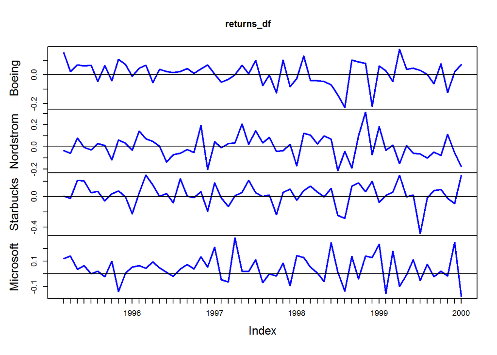

```r
# Timeplots with stocks on individual graphs
my.panel <- function(...) {
  lines(...)
  abline(h=0)
}
plot(returns_df, lwd=2, panel=my.panel, col="blue")
```

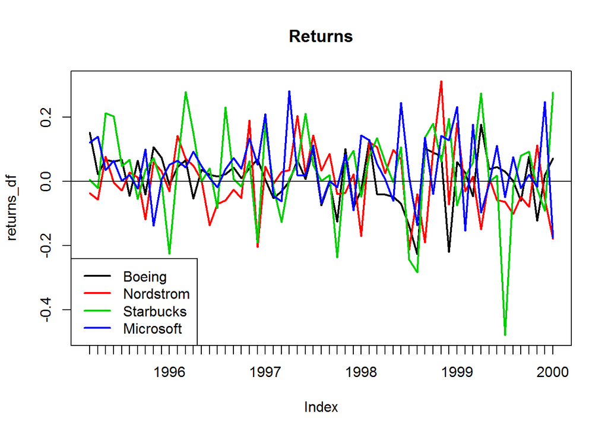

```r
# Timeplots with stocks on same graph
plot(returns_df, plot.type = "single", main="Returns", col=1:4, lwd=2)
abline(h=0)
legend(x="bottomleft", legend=colnames(returns_df), col=1:4, lwd=2)
```

The CER model

Before diving into the actual arithmetics, you first need to calculate the parameters of the constant expected return model (CER). Make use of the data in returns_df to estimate the model parameters for all four stocks.

```r
# All data is preloaded in your workspace.  Type 'ls()' in the console to see what has been loaded.

# Parameters CER model
mu_hat_month = apply(returns_df, 2, mean)
mu_hat_month
```

```
##    Boeing Nordstrom Starbucks Microsoft
##  0.011300  0.001545  0.028461  0.042712
```

```r
sigma2_month = apply(returns_df, 2, var)
sigma2_month
```

```
##    Boeing Nordstrom Starbucks Microsoft
##  0.006476  0.011121  0.020212  0.010122
```

```r
sigma_month = apply(returns_df, 2, sd)
sigma_month
```

```
##    Boeing Nordstrom Starbucks Microsoft
##   0.08047   0.10546   0.14217   0.10061
```

```r
cov_mat_month = var(returns_df)
cov_mat_month
```

```
##              Boeing Nordstrom Starbucks Microsoft
## Boeing    0.0064759  0.000870  0.003473 0.0006926
## Nordstrom 0.0008700  0.011121  0.002636 0.0018503
## Starbucks 0.0034735  0.002636  0.020212 0.0011305
## Microsoft 0.0006926  0.001850  0.001131 0.0101222
```

```r
cor_mat_month = cor(returns_df)
cor_mat_month
```

```
##            Boeing Nordstrom Starbucks Microsoft
## Boeing    1.00000    0.1025   0.30360   0.08554
## Nordstrom 0.10251    1.0000   0.17583   0.17439
## Starbucks 0.30360    0.1758   1.00000   0.07904
## Microsoft 0.08554    0.1744   0.07904   1.00000
```

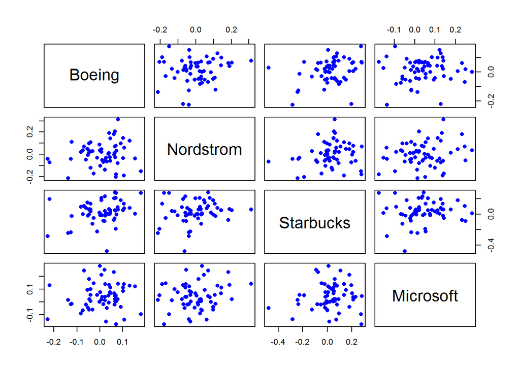

```r
# Pairwise scatterplots
pairs(coredata(returns_df), col="blue", pch=16)
```

The global minimum variance portfolio - Part One

In the previous lab you already determined the global minimum variance portfolio if short sales are allowed. Let us do a quick recap here: use globalMin.portfolio() to calculate the global minimum variance portfolio for your four stocks when you are allowed to take short positions.

```r
# All data and CER parameters are preloaded in your workspace.  Type 'ls()' in the console to see them.

# Calculate the global minimum variance portfolio
global_min_var_portfolio = globalMin.portfolio(mu_hat_month, cov_mat_month,shorts=TRUE)

global_min_var_portfolio
```

```
## Call:
## globalMin.portfolio(er = mu_hat_month, cov.mat = cov_mat_month,
##     shorts = TRUE)
##
## Portfolio expected return:     0.01846
## Portfolio standard deviation:  0.05927
## Portfolio weights:
##    Boeing Nordstrom Starbucks Microsoft
##    0.4562    0.2233    0.0512    0.2693
```

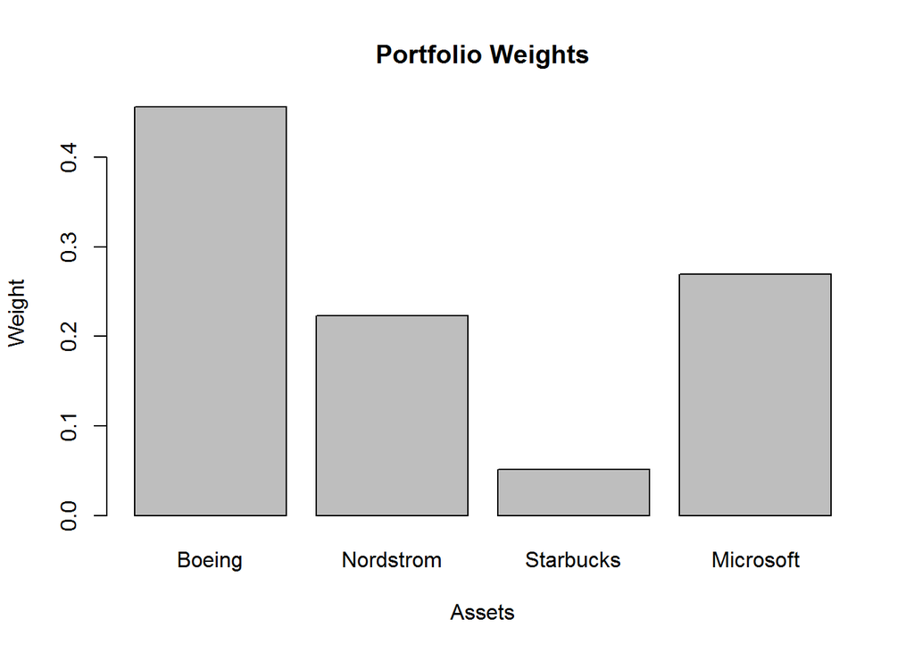

```r
# Plot the portfolio weights of our four stocks
plot(global_min_var_portfolio)
```

The global minimum variance portfolio - Part Two

Now you want to construct the global minimum variance portfolio under the condition that short sales are not allowed. The Markowitz portfolio optimization problem for the minimum variance portfolio with no short sales restrictions can be described as follows:

minx σ2p,x=x′∑x s.t. x′1=1 xi≥0, with x the vector of portfolio weights, σ2p,x and μp,x the portfolio variance and expected return respectively, μ the vector of expected returns and Σ the covariance matrix of the returns. As seen in the lectures, the portfolio optimization problem with inequality constraints can be set up as a quadratic programming problem. Quadratic programming problems are of the form:

minx 12x′Dx−d′x A′neqx≥bneq for m inequality constraints, and A′eqx=bneq for l equality constraints, where D is a n×n matrix, x and d are n×1 vectors, A′neq is an m×n matrix, bneq is an m×1 vector, A′eq is an l×n matrix, and beq is an l×1 vector. Quadratic programming problems can be solved with the R package quadprog and the solve.QP() function. In the next exercise you will discover a more easy way to do this with the help of globalMin.portfolio().

```r
# All data and CER parameters are preloaded in your workspace.  Type 'ls()' in the console to see them.

# set restriction matrices
D_matrix = 2* cov_mat_month
D_matrix
```

```
##             Boeing Nordstrom Starbucks Microsoft
## Boeing    0.012952  0.001740  0.006947  0.001385
## Nordstrom 0.001740  0.022242  0.005272  0.003701
## Starbucks 0.006947  0.005272  0.040424  0.002261
## Microsoft 0.001385  0.003701  0.002261  0.020244
```

```r
d_vector = rep(0,4)
d_vector
```

```
## [1] 0 0 0 0
```

```r
A_matrix = cbind(rep(1,4),diag(4))
A_matrix
```

```
##      [,1] [,2] [,3] [,4] [,5]
## [1,]    1    1    0    0    0
## [2,]    1    0    1    0    0
## [3,]    1    0    0    1    0
## [4,]    1    0    0    0    1
```

```r
b_vector = c(1,rep(0,4))
b_vector
```

```
## [1] 1 0 0 0 0
```

```r
# use solve.QP to minimize portfolio variance
library(quadprog)
quad_prog = solve.QP(Dmat = D_matrix,dvec = d_vector, Amat = A_matrix, bvec = b_vector, meq = 1)
quad_prog
```

```
## $solution
## [1] 0.45620 0.22325 0.05123 0.26932
##
## $value
## [1] 0.003513
##
## $unconstrained.solution
## [1] 0 0 0 0
##
## $iterations
## [1] 2 0
##
## $Lagrangian
## [1] 0.007026 0.000000 0.000000 0.000000 0.000000
##
## $iact
## [1] 1
```

The global minimum variance portfolio - End game

Even though the previous exercise provided a good insight in the calculation of a global minimum variance portfolio when short sales are not allowed, this way of working is somewhat complex. One of the great things of R is that you can “hide” this complexity in a function and/or package. You provide the input to the function via its arguments, and R does the rest. So instead of calculating the global minimum variance portfolio via the solve.QP() function, you can also use globalMin.portfolio() function.globalMin.portfolio() has an argument shorts and if you set this argument equal to FALSE, short sales are not allowed. In the background it is still solved as a quadratic programming problem, but as a user you are spared from these underlying details. You can always check the underlying code of the function by typing globalMin.portfolio in the console.

```r
# All data and CER parameters are preloaded in your workspace.  Type 'ls()' in the console to see them.

# The global minimum variance portfolio
global_min_var_portfolio  = globalMin.portfolio(mu_hat_month, cov_mat_month, shorts=FALSE)

global_min_var_portfolio
```

```
## Call:
## globalMin.portfolio(er = mu_hat_month, cov.mat = cov_mat_month,
##     shorts = FALSE)
##
## Portfolio expected return:     0.01846
## Portfolio standard deviation:  0.05927
## Portfolio weights:
##    Boeing Nordstrom Starbucks Microsoft
##    0.4562    0.2233    0.0512    0.2693
```

An efficient portfolio

You need to construct an efficient portfolio that uses the maximum average return as the target return. Consider two different scenarios: a scenario where short selling is allowed, and a scenario where short selling is forbidden. The minimization problem if short selling is allowed is: minm σ2p=x′∑x s.t. x′μ=μ0 x′1=1, with μ0 the target return and other symbols as defined before. If you do not allow for short sales, the following constraint is added: xi≥0 for all i.

```r
# All data and CER parameters are preloaded in your workspace.  Type 'ls()' in the console to see them.

# highest average return
mu_target = max(mu_hat_month)

# short sales allowed
efficient_porfolio_short = efficient.portfolio(mu_hat_month, cov_mat_month, mu_target,shorts=TRUE)
efficient_porfolio_short
```

```
## Call:
## efficient.portfolio(er = mu_hat_month, cov.mat = cov_mat_month,
##     target.return = mu_target, shorts = TRUE)
##
## Portfolio expected return:     0.04271
## Portfolio standard deviation:  0.09111
## Portfolio weights:
##    Boeing Nordstrom Starbucks Microsoft
##    0.1404   -0.1852    0.2257    0.8192
```

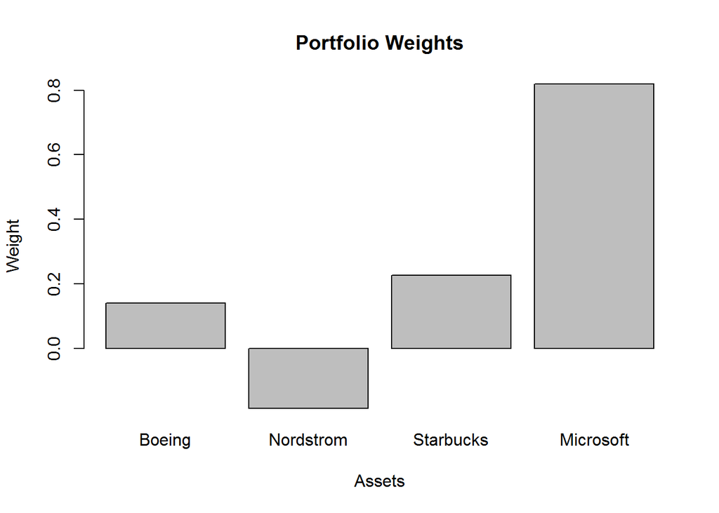

```r
plot(efficient_porfolio_short)
```

```r
# no short sales allowed
efficient_porfolio_no_short = efficient.portfolio(mu_hat_month, cov_mat_month, mu_target,shorts=FALSE)
efficient_porfolio_no_short
```

```
## Call:
## efficient.portfolio(er = mu_hat_month, cov.mat = cov_mat_month,
##     target.return = mu_target, shorts = FALSE)
##
## Portfolio expected return:     0.04271
## Portfolio standard deviation:  0.1006
## Portfolio weights:
##    Boeing Nordstrom Starbucks Microsoft
##         0         0         0         1
```

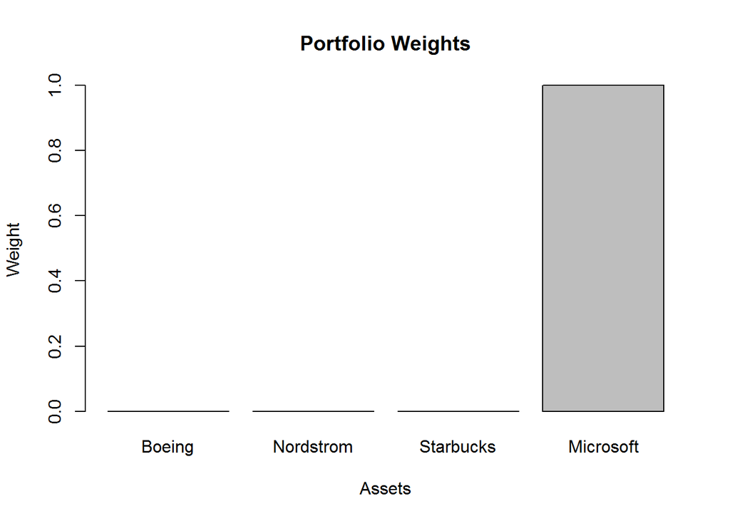

```r
plot(efficient_porfolio_no_short)
```

The efficient frontier

Using the fact that all efficient portfolios can be written as a convex combination of two efficient portfolios, you can compute efficient portfolios as convex combinations of the global minimum variance portfolio and the efficient portfolio calculated in the previous exercise: z=α∗m+(1−α)∗x for values of α being between −1 and 1, with m the vector of portfolio weights of the global minimum variance portfolio and with x the vector of portfolio weights of the efficient portfolio that was calculated in the previous exercise.

```r
# All data and CER parameters are preloaded in your workspace.  Type 'ls()' in the console to see them.

# The efficient frontier of risky assets
efficient_frontier = efficient.frontier(mu_hat_month, cov_mat_month, alpha.min=-1, alpha.max=1)
summary(efficient_frontier)
```

```
## Frontier portfolios' expected returns and standard deviations
##    port 1 port 2 port 3 port 4 port 5 port 6 port 7 port 8 port 9 port 10
## ER 0.0670 0.0644 0.0619 0.0593 0.0568 0.0542 0.0516 0.0491 0.0465  0.0440
## SD 0.1506 0.1439 0.1373 0.1307 0.1243 0.1179 0.1117 0.1056 0.0997  0.0939
##    port 11 port 12 port 13 port 14 port 15 port 16 port 17 port 18 port 19
## ER  0.0414  0.0389  0.0363  0.0338  0.0312  0.0287  0.0261  0.0236  0.0210
## SD  0.0884  0.0831  0.0782  0.0736  0.0696  0.0660  0.0632  0.0610  0.0597
##    port 20
## ER  0.0185
## SD  0.0593
##
## Portfolio weights:
##          Boeing Nordstrom Starbucks Microsoft
## port 1  -0.1755   -0.5937    0.4002    1.3690
## port 2  -0.1423   -0.5507    0.3818    1.3111
## port 3  -0.1090   -0.5077    0.3635    1.2533
## port 4  -0.0758   -0.4647    0.3451    1.1954
## port 5  -0.0425   -0.4217    0.3267    1.1375
## port 6  -0.0093   -0.3787    0.3084    1.0796
## port 7   0.0240   -0.3357    0.2900    1.0217
## port 8   0.0572   -0.2927    0.2716    0.9639
## port 9   0.0905   -0.2497    0.2533    0.9060
## port 10  0.1237   -0.2067    0.2349    0.8481
## port 11  0.1570   -0.1637    0.2165    0.7902
## port 12  0.1902   -0.1207    0.1982    0.7323
## port 13  0.2235   -0.0777    0.1798    0.6745
## port 14  0.2567   -0.0347    0.1614    0.6166
## port 15  0.2900    0.0083    0.1431    0.5587
## port 16  0.3232    0.0513    0.1247    0.5008
## port 17  0.3565    0.0943    0.1063    0.4430
## port 18  0.3897    0.1373    0.0880    0.3851
## port 19  0.4230    0.1803    0.0696    0.3272
## port 20  0.4562    0.2233    0.0512    0.2693
```

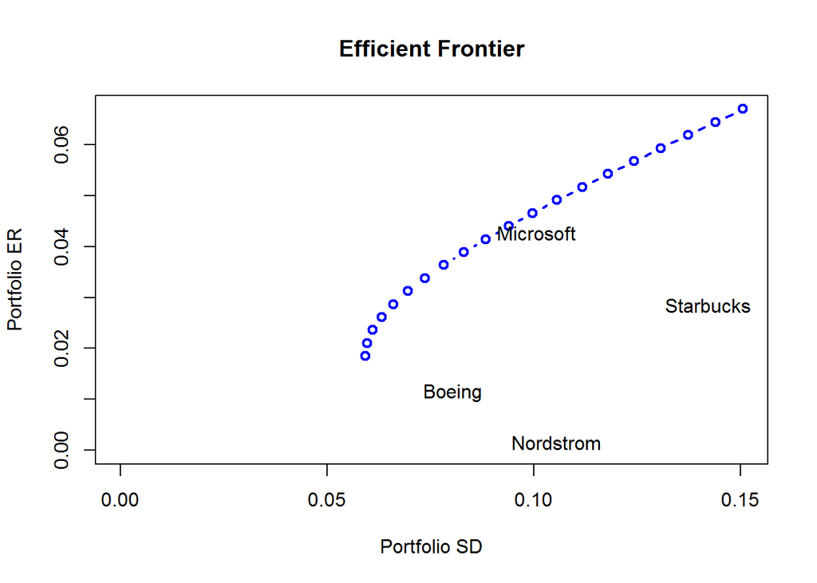

```r
# The plot
plot(efficient_frontier, plot.assets=TRUE, col="blue", lwd=2)
```

The tangency portfolio

Let us see how the weights of the underlying assets of the tangency portfolio depend on whether or not short positions are allowed. Assume the risk-free rate is 0.005 (rf = 0.5%) per month. The tangency portfolio can be found via: maxt slope = μp−rfσp subject to μp=t′μ σp=(t′∑t)1/2 t′1=1, with μp and σp the portfolio return and standard deviation respectively, t the vector of portfolio weights, μ the vector of expected returns and Σ the covariance matrix of the returns. If you add the condition that no short positions are allowed, the additional constraint that is to be added is xi≥ for i=1,…,4. Luckily, the underlying arithmetics are encapsulated in the R function tangency.portfolio(). Again, smart use of these functions can make your work as a financial analyst considerably lighter.

```r
# All data and CER parameters are preloaded in your workspace.  Type 'ls()' in the console to see them.

# risk free rate
t_bill_rate = 0.005

# Tangency portfolio short sales allowed
tangency_portfolio_short = tangency.portfolio(mu_hat_month, cov_mat_month, risk.free=t_bill_rate,shorts=TRUE)
summary(tangency_portfolio_short)
```

```
## Call:
## tangency.portfolio(er = mu_hat_month, cov.mat = cov_mat_month,
##     risk.free = t_bill_rate, shorts = TRUE)
##
## Portfolio expected return:     0.05051
## Portfolio standard deviation:  0.109
## Portfolio weights:
##    Boeing Nordstrom Starbucks Microsoft
##    0.0387   -0.3166    0.2818    0.9960
```

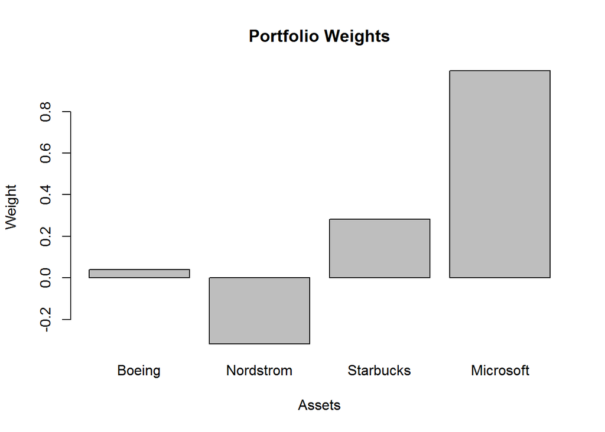

```r
#plot
plot(tangency_portfolio_short)
```

```r
# Tangency portfolio short sales not allowed
tangency_portfolio_no_short = tangency.portfolio(mu_hat_month, cov_mat_month, risk.free=t_bill_rate,shorts=FALSE)
summary(tangency_portfolio_no_short)
```

```
## Call:
## tangency.portfolio(er = mu_hat_month, cov.mat = cov_mat_month,
##     risk.free = t_bill_rate, shorts = FALSE)
##
## Portfolio expected return:     0.03927
## Portfolio standard deviation:  0.08595
## Portfolio weights:
##    Boeing Nordstrom Starbucks Microsoft
##    0.0171    0.0000    0.2037    0.7792
```

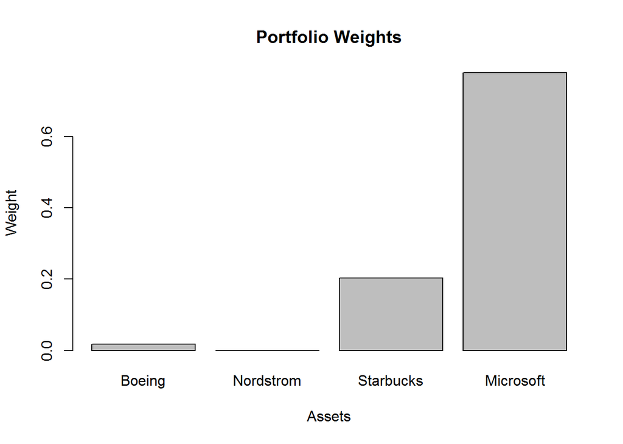

```r
#plot
plot(tangency_portfolio_no_short)
```

Question 1 (10) Which two assets have the highest correlation?

```r
cor_mat_month
```

```
##            Boeing Nordstrom Starbucks Microsoft
## Boeing    1.00000    0.1025   0.30360   0.08554
## Nordstrom 0.10251    1.0000   0.17583   0.17439
## Starbucks 0.30360    0.1758   1.00000   0.07904
## Microsoft 0.08554    0.1744   0.07904   1.00000
```

Question 2 (10) What is the weight of Microsoft in the global minimum variance portfolio?

```r
global_min_var_portfolio$weights
```

```
##    Boeing Nordstrom Starbucks Microsoft
##   0.45621   0.22325   0.05123   0.26932
```

Question 3 (10) What is the standard deviation of the global minimum variance portfolio?

```r
global_min_var_portfolio$sd
```

```
## [1] 0.05927
```

Question 4 (10) What is the expected return of the global minimum variance portfolio?

```r
global_min_var_portfolio$er
```

```
## [1] 0.01846
```

Question 5 (10) What happens to the global minimum variance portfolio if short sales are restricted? no change

Question 6 (10) Of the four stocks, determine the stock with the largest estimated expected return. Use this maximum average return as the target return for the computation of an efficient portfolio allowing for short-sales. What is the weight of Microsoft in this portfolio?

```r
efficient.portfolio(mu_hat_month, cov_mat_month, mu_target,shorts=TRUE)
```

```
## Call:
## efficient.portfolio(er = mu_hat_month, cov.mat = cov_mat_month,
##     target.return = mu_target, shorts = TRUE)
##
## Portfolio expected return:     0.04271
## Portfolio standard deviation:  0.09111
## Portfolio weights:
##    Boeing Nordstrom Starbucks Microsoft
##    0.1404   -0.1852    0.2257    0.8192
```

Question 7 (10) Of the four stocks, determine the stock with the largest estimated expected return. Use this maximum average return as the target return for the computation of an efficient portfolio not allowing for short-sales. What is the weight of Microsoft in this portfolio?

```r
efficient.portfolio(mu_hat_month, cov_mat_month, mu_target,shorts=FALSE)
```

```
## Call:
## efficient.portfolio(er = mu_hat_month, cov.mat = cov_mat_month,
##     target.return = mu_target, shorts = FALSE)
##
## Portfolio expected return:     0.04271
## Portfolio standard deviation:  0.1006
## Portfolio weights:
##    Boeing Nordstrom Starbucks Microsoft
##         0         0         0         1
```

Question 8 (10) Using the fact that all efficient portfolios can be written as a convex combination of two efficient portfolios, compute efficient portfolios as convex combinations of the global minimum variance portfolio and the efficient portfolio that was computed in question six. What is the expected return of the portfolio when α=.5?

Question 9 (10) What is the weight of Microsoft in the tangency portfolio with short sales allowed?

```r
tangency_portfolio_short$weights
```

```
##    Boeing Nordstrom Starbucks Microsoft
##   0.03874  -0.31664   0.28185   0.99605
```

Question 10 (10) What is the weight of Microsoft in the tangency portfolio with short sales not allowed?

```r
tangency_portfolio_no_short$weights
```

```
##    Boeing Nordstrom Starbucks Microsoft
##   0.01714   0.00000   0.20368   0.77918
```